# act_report.

[figure not shown]

**We Rate Dogs is a Twitter account that rates people's dogs with a humorous comment about the dog. These ratings almost always have a denominator of 10. The numerators, though? Almost always greater than 10. 11/10, 12/10, 13/10**  
**in the next few lines we are going to find answers to some questions about this account Data**

**Is there a relationship between Retweet count and Favourite count?**

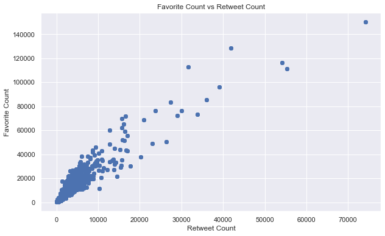

**In the Figure above it appears that the number of retweets is directly proportional with the number of favorites,which gives us an insight of how users interact with different tweets**

**What are The top five petted breeds?**

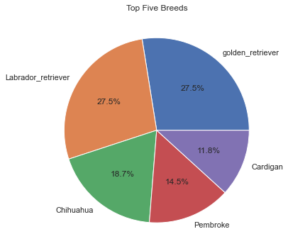

**This Figure above shows the top five breeds,out of them both the golden retriever and labrador retriever appear to be the top two breeds predicted with the same percent, which gives us an insight that people love to pet those two breeds the most**

**What is the dog-stage with the highest rate?**

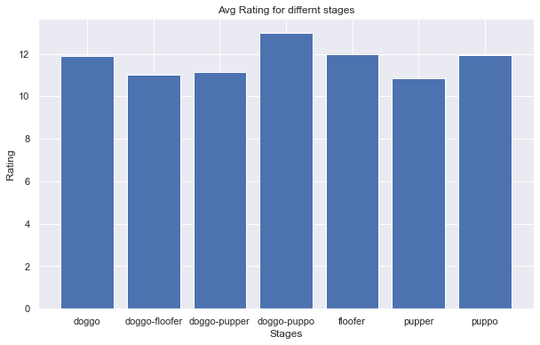

**from this figure we get that the doggo-puppo stage is the most rated one out of all the stages,it is also the only one that exeeds the average rating 12,doggo and puppo are quite in the same rank just under 12.**

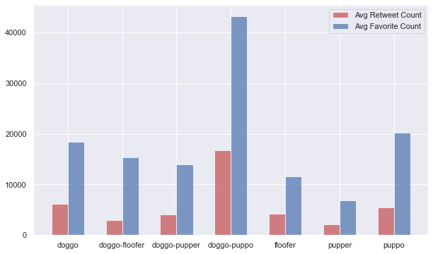

**In this visualization we see that the doggo-puppo stage comes with the most favorite count,retweet count also is quite high in regerad with the other different stages,which draws conclusions that its the most like dog stage of all,and pupper stage is quite the opposite. we get also from the numbers of retweets and favorites that people tend to interact with tweets in the form of favorite more than retweets.**

# Conclusion

**There is a strong relationship between Retweets and favourites as the more users retweet the more other can see the tweets and favorites. The top five breeds are Golden Retriever, Labrador Retriever, Chihuaha, Pembroke, and Cardigan, with both Retriever breeds at the top. Doggo-Puppo Stage comes also at the top as the most liked dog stage of all**